# AIRLINE PASSENGERS SATISFACTION: CLASSIFICATION

16/06/2023

## Project description

For our project we decided to analyze the “airlines customer satisfaction” dataset available on kaggle. This dataset contains information on passangers who have already flown with the airline that provided this data. These cover general characteristics of the passenger (age, gender, etc.), and of the type of flight (distance, class, etc.), feedback on different aspects of the experience the customers had, as well as their level of satisfaction in general.

As the goal of our work, we tried to extract insights that might be of interest to the company that owns the data in order to improve their service and strategy. With this idea, we structured the analysis in this way: 1) Exploratory data analysis, to understand and visualize the data provided; 2) Clustering of passengers, in order to identify their different characteristics and enable the company to better target its efforts; 3) Creation of a model to predict whether or not a passenger will be satisfied given the variables examined

## Variable description

- …1: Index column
- Gender: Refers to the gender of the customer, either male or female.
- Customer Type: Indicates whether the customer is a loyal customer (someone who frequently chooses the same airline or company) or a disloyal customer (someone who doesn’t consistently choose the same airline or company).
- Age: Represents the age of the customer.
- Type of Travel: Specifies the purpose of the customer’s travel, such as personal travel or business travel.
- Customer Class: Indicates the class or category in which the customer traveled, such as Economy Plus or Business.
- Flight Distance: Represents the distance traveled by the customer’s flight.
- Inflight Wi-Fi Service: Rates the satisfaction level of the customer with the inflight Wi-Fi service on a scale of 0 to 5.
- Departure/Arrival Time Convenience: Rates the satisfaction level of the customer with the convenience of departure and arrival times on a scale of 0 to 5.
- Ease of Online Booking: Rates the satisfaction level of the customer with the ease of booking flights online on a scale of 0 to 5.
- Gate Location: Rates the satisfaction level of the customer with the gate location at the airport on a scale of 0 to 5.
- Food and Drink: Rates the satisfaction level of the customer with the quality of food and drink provided on the flight on a scale of 0 to 5.
- Online Boarding: Rates the satisfaction level of the customer with the online boarding process on a scale of 0 to 5.
- Seat Comfort: Rates the satisfaction level of the customer with the comfort of the seats on the flight on a scale of 0 to 5.
- Inflight Entertainment: Rates the satisfaction level of the customer with the inflight entertainment options on a scale of 0 to 5.
- Onboard Service: Rates the satisfaction level of the customer with the service provided by the flight crew on a scale of 0 to 5.
- Leg Room Service: Rates the satisfaction level of the customer with the legroom space on the flight on a scale of 0 to 5.
- Baggage Handling: Rates the satisfaction level of the customer with the handling of baggage by the airline on a scale of 1 to 5.
- Check-in Service: Rates the satisfaction level of the customer with the check-in service at the airport on a scale of 0 to 5.
- Inflight Service: Rates the satisfaction level of the customer with the overall inflight service on a scale of 0 to 5.
- Cleanliness: Rates the satisfaction level of the customer with the cleanliness of the aircraft on a scale of 0 to 5.
- Departure Delay in Minutes: Specifies the number of minutes of departure delay experienced by the customer.
- Arrival Delay in Minutes: Specifies the number of minutes of arrival delay experienced by the customer.
- Satisfaction: Represents the overall satisfaction level of the customer with their travel experience, categorized as either “satisfied” or “neutral or dissatisfied”

**Rewrite the outline**

# OUTLINE

1. **Data upload**
2. **Exploratory analysis:**
   - missing values handling
   - outliers analysis:
     - IQR method
     - 3*SD method
   - data cleaning
   - descriptive analysis:
     - satisfaction distribution
     - customers information
     - customer-generated variables
     - numerical variables
   - correlation matrix
3. **Train and test sets split**
4. **Logistic regression:**
   - general logistic model
   - forward step-wise models analysis
   - cross-validation
   - models comparison based on R-squared, CV error, CP
   - models selection (maybe one model per criteria if they differs)
   - models evaluation (accuracy, specificity, sensitivity, …)
   - ROC curve
5. **Linear Discriminant Analysis:**
   - …
   - compare LDA and logistic
6. **Tree predictors:**
   - …
   - comparison with logistic model
7. **Conclusion and Interpretation**

## Libraries **Put all the libraries used here**

```r
set.seed(123)
library(tidyverse)
library(dplyr)
library(ggplot2)
library(grid)
library(gridExtra)
library(corrr)
library(ggradar)
library(scales)
library(tibble)
# ggradar needs to be installed from github
# > install.packages("remotes")
# > remotes::install_github("ricardo-bion/ggradar")
```

# **1) DATA**

```r
df <- read_csv("dataset/airline_passenger_satisfaction.csv")
```

Give more compact names to columns

```r
df <- df %>% rename(gender = Gender, cust_type = customer_type,
                    trav_type = type_of_travel,
                    class = customer_class,
                    distance = flight_distance,
                    wifi = inflight_wifi_service,
                    time_conv = departure_arrival_time_convenient,
                    onl_book = ease_of_online_booking,
                    gate_loc = gate_location,
                    food = food_and_drink,
                    onl_board = online_boarding,
                    comfort = seat_comfort,
                    entert = inflight_entertainment,
                    onb_serv  = onboard_service,
                    leg_room = leg_room_service,
                    baggage = baggage_handling,
                    checkin = checkin_service,
                    infl_serv = inflight_service,
                    clean = cleanliness,
                    dep_delay = departure_delay_in_minutes,
                    arr_delay = arrival_delay_in_minutes,
                    sat = satisfaction)
```

The zero rating corresponds to a missing answer for that variable. For this reason we decided to remove the rows where a zero appears.

```r
summary(df_filtered)
```

[output not shown]

```r
# Subset the df and replace 0 with NA only in the rating variable

df[df == 0] <- NA
df <- na.omit(df)
```

### Dataset structure

```r
summary(df)
```

```
      ...1           gender           cust_type              age        trav_type            class              distance
 Min.   :     1   Length:39908       Length:39908       Min.   : 7.0   Length:39908       Length:39908       Min.   :  31
 1st Qu.: 32183   Class :character   Class :character   1st Qu.:27.0   Class :character   Class :character   1st Qu.: 442
 Median : 64562   Mode  :character   Mode  :character   Median :40.0   Mode  :character   Mode  :character   Median : 853
 Mean   : 64636                                         Mean   :39.6                                         Mean   :1206
 3rd Qu.: 97021                                         3rd Qu.:51.0                                         3rd Qu.:1739
 Max.   :129872                                         Max.   :85.0                                         Max.   :4963
      wifi         time_conv        onl_book        gate_loc          food         onl_board        comfort        entert
 Min.   :1.000   Min.   :1.000   Min.   :1.000   Min.   :1.000   Min.   :1.000   Min.   :1.000   Min.   :1.0   Min.   :1.000
 1st Qu.:2.000   1st Qu.:2.000   1st Qu.:2.000   1st Qu.:2.000   1st Qu.:2.000   1st Qu.:2.000   1st Qu.:2.0   1st Qu.:2.000
 Median :3.000   Median :3.000   Median :3.000   Median :3.000   Median :3.000   Median :3.000   Median :4.0   Median :4.000
 Mean   :2.739   Mean   :3.187   Mean   :2.842   Mean   :2.997   Mean   :3.165   Mean   :3.242   Mean   :3.4   Mean   :3.305
 3rd Qu.:4.000   3rd Qu.:4.000   3rd Qu.:4.000   3rd Qu.:4.000   3rd Qu.:4.000   3rd Qu.:4.000   3rd Qu.:4.0   3rd Qu.:4.000
 Max.   :5.000   Max.   :5.000   Max.   :5.000   Max.   :5.000   Max.   :5.000   Max.   :5.000   Max.   :5.0   Max.   :5.000
    onb_serv       leg_room        baggage         checkin        infl_serv         clean         dep_delay         arr_delay
 Min.   :1.00   Min.   :1.000   Min.   :1.000   Min.   :1.000   Min.   :1.000   Min.   :1.000   Min.   :   1.00   Min.   :   1.00
 1st Qu.:2.00   1st Qu.:2.000   1st Qu.:3.000   1st Qu.:2.000   1st Qu.:3.000   1st Qu.:2.000   1st Qu.:  11.00   1st Qu.:  10.00
 Median :3.00   Median :4.000   Median :4.000   Median :3.000   Median :4.000   Median :3.000   Median :  24.00   Median :  24.00
 Mean   :3.31   Mean   :3.349   Mean   :3.593   Mean   :3.246   Mean   :3.577   Mean   :3.242   Mean   :  42.49   Mean   :  42.48
 3rd Qu.:4.00   3rd Qu.:4.000   3rd Qu.:4.000   3rd Qu.:4.000   3rd Qu.:4.000   3rd Qu.:4.000   3rd Qu.:  52.00   3rd Qu.:  52.00
 Max.   :5.00   Max.   :5.000   Max.   :5.000   Max.   :5.000   Max.   :5.000   Max.   :5.000   Max.   :1592.00   Max.   :1584.00
     sat
 Length:39908
 Class :character
 Mode  :character
```

Remove the index column

```r
df <- df[-1]
```

# **2) EXPLANATORY ANALYSIS**

The NA values have been already removed, so we can skip this part.

## Handling missing values

```r
# Function that counts NA values for each column
na_counts <- sapply(df, function(x) sum(is.na(x)))


# Calculate the percentage of NA values for each column
na_percentage <- na_counts / nrow(df) * 100

# Display a table with NA counts and percentages
na_table <- data.frame(Column = names(na_counts), NA_Count = na_counts, Percentage = na_percentage, row.names = NULL)

# na_table <- na_table[-1,]
na_table
```

| Column | NA_Count | Percentage |
| --- | --- | --- |
| gender | 0 | 0 |
| cust_type | 0 | 0 |
| age | 0 | 0 |
| trav_type | 0 | 0 |
| class | 0 | 0 |
| distance | 0 | 0 |
| wifi | 0 | 0 |
| time_conv | 0 | 0 |
| onl_book | 0 | 0 |
| gate_loc | 0 | 0 |

[output cut: 13 more lines]

```r
# Count NA values in departure delay when the arrival delay is zero
zero_count <- sum(df$dep_delay == 0 & is.na(df$arr_delay))

zero_count
```

```
[1] 0
```

```r
correlation_dep_arr <- cor(df$dep_delay, df$arr_delay, use = "complete.obs")

correlation_dep_arr
```

```
[1] 0.9658849
```

```r
df <- df %>% select(- dep_delay)
```

## Outliers analysis

The majority of variables take values on a fixed scale. The variables worth checking for outliers are: *departure delay in minutes*, *arrival delay in minutes*, *flight distance*.

```r
par(mfrow = c(1, 2))

plot(df$departure_delay_in_minutes, main = "Departure Delay",
     xlab = "Index", ylab = "Departure delay in minutes", col = "darkred")

plot(df$arrival_delay_in_minutes, main = "Arrival Delay",
     xlab = "Index", ylab = "Arrival delay in minutes", col = "darkgreen")
```

## Inter Quantile Range method

```r
Q1 <- quantile(df$departure_delay_in_minutes, 0.25)
Q3 <- quantile(df$departure_delay_in_minutes, 0.75)
IQR <- Q3 - Q1

lower_threshold <- Q1 - 1.5 * IQR
upper_threshold <- Q3 + 1.5 * IQR

iqr_outliers <- df$departure_delay_in_minutes[df$departure_delay_in_minutes < Q1 - 1.5 * IQR |
                                              df$departure_delay_in_minutes > Q3 + 1.5 * IQR]
iqr_outlier_count <- length(iqr_outliers)

c("Outliers identified with the IQR method:", iqr_outlier_count)
c("Percentage of outliers identified:", iqr_outlier_count / length(df$departure_delay_in_minutes) * 100)
```

```r
Q1 <- quantile(df$arrival_delay_in_minutes, 0.25)
Q3 <- quantile(df$arrival_delay_in_minutes, 0.75)
IQR <- Q3 - Q1

lower_threshold <- Q1 - 1.5 * IQR
upper_threshold <- Q3 + 1.5 * IQR

iqr_outliers <- df$arrival_delay_in_minutes[df$arrival_delay_in_minutes < Q1 - 1.5 * IQR |
                                              df$arrival_delay_in_minutes > Q3 + 1.5 * IQR]
iqr_outlier_count <- length(iqr_outliers)

c("Outliers identified with the IQR method:", iqr_outlier_count)
c("Percentage of outliers identified:", iqr_outlier_count / length(df$departure_delay_in_minutes) * 100)
```

## SD method

```r
z_scores_dep <- scale(df$departure_delay_in_minutes)
z_scores_arr <- scale(df$arrival_delay_in_minutes)

outliers_dep <- which(abs(z_scores_dep) > 3)
outliers_arr <- which(abs(z_scores_arr) > 3)

sd_outliers_count_dep <- length(outliers_dep)
sd_outliers_count_arr <- length(outliers_arr)

c("Observations that falls over 3 times the sd (departure delay):", sd_outliers_count_dep)
c("Percentage of outliers identified (departure delay):", sd_outliers_count_dep / length(df$departure_delay_in_minutes) * 100)

c("Observations that falls over 3 times the sd (arrival delay):", sd_outliers_count_arr)
c("Percentage of outliers identified (arrival delay):", sd_outliers_count_arr / length(df$arrival_delay_in_minutes) * 100)
```

```r
plot(df$flight_distance, main = "Flight Distance",
     xlab = "Index", ylab = "Flight distance", col = "darkblue")
```

```r
z_scores_dist <- scale(df$flight_distance)

outliers_dist <- which(abs(z_scores_dist) > 3)

sd_outliers_count_dist <- length(outliers_dist)

c("Observations that falls over 3 times the sd (flight distance):", sd_outliers_count_dist)
c("Percentage of outliers identified (flight distance):", sd_outliers_count_dist / length(df$flight_distance) * 100)
```

[For now I will not remove any outliers]

```r
# plot(df$age, main = "Customers' Age",
#     xlab = "Index", ylab = "Age")
# Is it worth plotting age too?
```

# Descriptive analysis

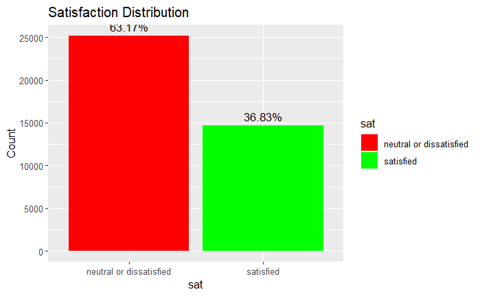

```r
p_satisf <- ggplot(df, aes(x = sat)) +
  geom_bar(aes(fill = sat)) +
  geom_text(aes(y = ..count..,
                label = paste0(round(prop.table(..count..), 4) * 100, '%')),
            stat = 'count',
            position = position_dodge(0.3),
            size = 4,
            vjust = - 0.5) +
  scale_fill_manual(values = c("red", "green")) +
  labs(title = "Satisfaction Distribution", y = "Count")

p_satisf
```

### Define function to plot bar charts

```r
# Plot bar chart function
plot_bar_chart <- function(df, var_name) {
  var_name <- enquo(var_name)  # Defuse the var_name so it can be evaluated later

  plot_var <- ggplot(df, aes(x = !!var_name)) +  # !! to inject the var_name back to evaluate it
    geom_bar(aes(fill = sat)) +
    geom_text(aes(y = ..count..,
                  label = paste0(round(prop.table(..count..), 4) * 100, '%')),
              stat = 'count',
              position = position_dodge(0.3),
              size = 4,
              vjust = -0.5) +
    scale_fill_manual(values = c("red", "green")) +
    labs(title = paste0("Satisfaction Distribution for ", quo_name(var_name)),
         x = quo_name(var_name), y = "Count")  # quo_name() to return the var_name as string

  print(plot_var)
}
```

### Customers information Variables

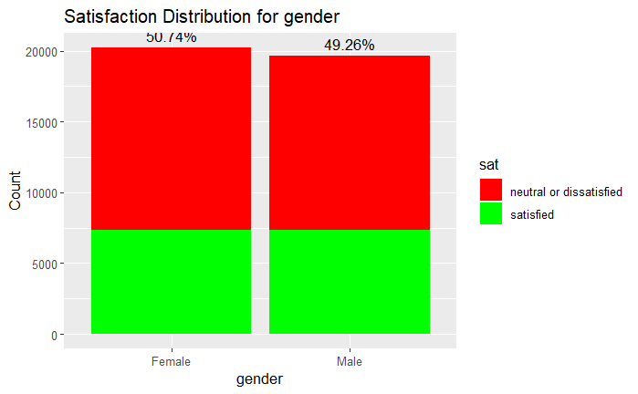

```r
# Gender
plot_bar_chart(df, gender)
```

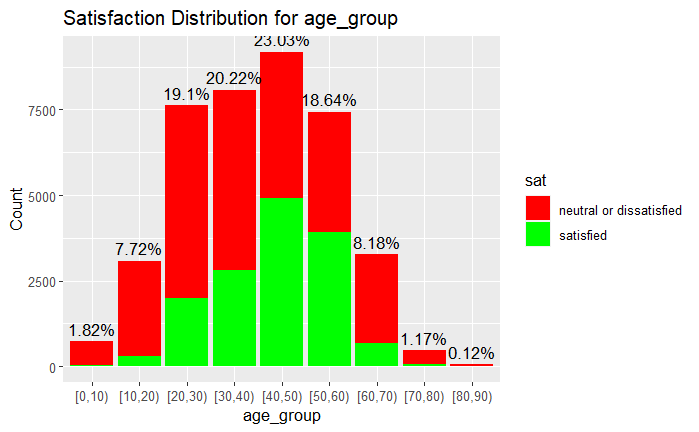

```r
# Age
df$age_group <- cut(df$age, breaks = seq(0, max(df$age) + 10, by = 10), right = FALSE)
plot_bar_chart(df, age_group)
```

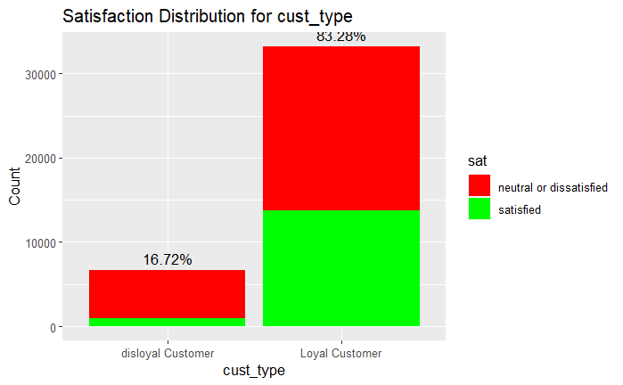

```r
# Customer type
plot_bar_chart(df, cust_type)
```

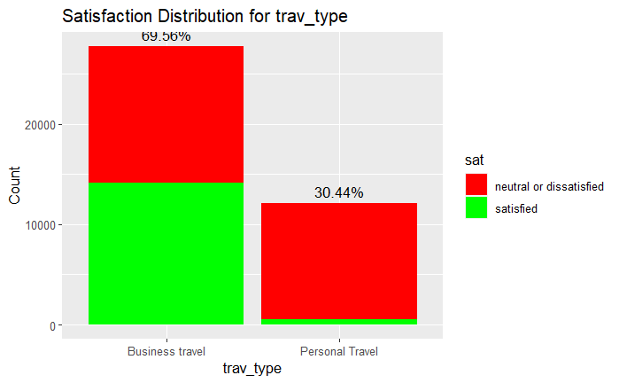

```r
# Type of travel
plot_bar_chart(df, trav_type)
```

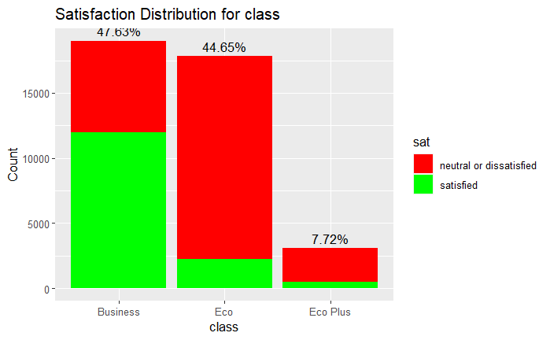

```r
# Customer class
plot_bar_chart(df, class)
```

```r
summary(df)
```

```
    gender           cust_type              age        trav_type            class              distance         wifi
 Length:39908       Length:39908       Min.   : 7.0   Length:39908       Length:39908       Min.   :  31   Min.   :1.000
 Class :character   Class :character   1st Qu.:27.0   Class :character   Class :character   1st Qu.: 442   1st Qu.:2.000
 Mode  :character   Mode  :character   Median :40.0   Mode  :character   Mode  :character   Median : 853   Median :3.000
                                       Mean   :39.6                                         Mean   :1206   Mean   :2.739
                                       3rd Qu.:51.0                                         3rd Qu.:1739   3rd Qu.:4.000
                                       Max.   :85.0                                         Max.   :4963   Max.   :5.000

   time_conv        onl_book        gate_loc          food         onl_board        comfort        entert         onb_serv
 Min.   :1.000   Min.   :1.000   Min.   :1.000   Min.   :1.000   Min.   :1.000   Min.   :1.0   Min.   :1.000   Min.   :1.00
 1st Qu.:2.000   1st Qu.:2.000   1st Qu.:2.000   1st Qu.:2.000   1st Qu.:2.000   1st Qu.:2.0   1st Qu.:2.000   1st Qu.:2.00
 Median :3.000   Median :3.000   Median :3.000   Median :3.000   Median :3.000   Median :4.0   Median :4.000   Median :3.00
 Mean   :3.187   Mean   :2.842   Mean   :2.997   Mean   :3.165   Mean   :3.242   Mean   :3.4   Mean   :3.305   Mean   :3.31
 3rd Qu.:4.000   3rd Qu.:4.000   3rd Qu.:4.000   3rd Qu.:4.000   3rd Qu.:4.000   3rd Qu.:4.0   3rd Qu.:4.000   3rd Qu.:4.00
 Max.   :5.000   Max.   :5.000   Max.   :5.000   Max.   :5.000   Max.   :5.000   Max.   :5.0   Max.   :5.000   Max.   :5.00

    leg_room        baggage         checkin        infl_serv         clean         arr_delay           sat              age_group
 Min.   :1.000   Min.   :1.000   Min.   :1.000   Min.   :1.000   Min.   :1.000   Min.   :   1.00   Length:39908       [40,50):9190
 1st Qu.:2.000   1st Qu.:3.000   1st Qu.:2.000   1st Qu.:3.000   1st Qu.:2.000   1st Qu.:  10.00   Class :character   [30,40):8070
 Median :4.000   Median :4.000   Median :3.000   Median :4.000   Median :3.000   Median :  24.00   Mode  :character   [20,30):7624
 Mean   :3.349   Mean   :3.593   Mean   :3.246   Mean   :3.577   Mean   :3.242   Mean   :  42.48                      [50,60):7437
 3rd Qu.:4.000   3rd Qu.:4.000   3rd Qu.:4.000   3rd Qu.:4.000   3rd Qu.:4.000   3rd Qu.:  52.00                      [60,70):3264
 Max.   :5.000   Max.   :5.000   Max.   :5.000   Max.   :5.000   Max.   :5.000   Max.   :1584.00                      [10,20):3081
                                                                                                                      (Other):1242
```

Dropping group_age because it is not needed anymore (we will only use age)

```r
df <- df%>% select(-age_group)
df
```

| gender | cust_type | age | trav_type | class | distance | wifi | time_conv | onl_book | gate_loc | food | onl_board | comfort | entert | onb_serv | leg_room | baggage | checkin | infl_serv | clean | arr_delay | sat |
| --- | --- | --- | --- | --- | --- | --- | --- | --- | --- | --- | --- | --- | --- | --- | --- | --- | --- | --- | --- | --- | --- |
| Male | disloyal Customer | 25 | Business travel | Business | 235 | 3 | 2 | 3 | 3 | 1 | 3 | 1 | 1 | 1 | 5 | 3 | 1 | 4 | 1 | 6 | neutral or dissatisfied |
| Female | Loyal Customer | 25 | Business travel | Business | 562 | 2 | 5 | 5 | 5 | 2 | 2 | 2 | 2 | 2 | 5 | 3 | 1 | 4 | 2 | 9 | neutral or dissatisfied |
| Male | Loyal Customer | 47 | Personal Travel | Eco | 1276 | 2 | 4 | 2 | 3 | 2 | 2 | 2 | 2 | 3 | 3 | 4 | 3 | 5 | 2 | 23 | neutral or dissatisfied |
| Male | Loyal Customer | 53 | Business travel | Eco | 834 | 1 | 4 | 4 | 4 | 1 | 1 | 1 | 1 | 1 | 1 | 3 | 4 | 4 | 1 | 8 | neutral or dissatisfied |
| Female | Loyal Customer | 26 | Personal Travel | Eco | 453 | 3 | 2 | 3 | 2 | 2 | 3 | 2 | 2 | 4 | 3 | 2 | 2 | 1 | 2 | 35 | neutral or dissatisfied |
| Female | Loyal Customer | 26 | Business travel | Business | 2123 | 3 | 3 | 3 | 3 | 4 | 4 | 4 | 4 | 5 | 3 | 4 | 5 | 4 | 4 | 51 | satisfied |
| Female | Loyal Customer | 45 | Business travel | Business | 2486 | 4 | 4 | 4 | 4 | 3 | 4 | 5 | 5 | 5 | 5 | 5 | 3 | 5 | 4 | 5 | satisfied |
| Male | Loyal Customer | 38 | Personal Travel | Eco | 460 | 2 | 3 | 3 | 2 | 5 | 3 | 5 | 5 | 1 | 2 | 4 | 3 | 2 | 5 | 18 | neutral or dissatisfied |
| Female | Loyal Customer | 43 | Personal Travel | Eco | 752 | 3 | 5 | 3 | 5 | 5 | 4 | 5 | 3 | 3 | 3 | 5 | 3 | 3 | 4 | 29 | neutral or dissatisfied |
| Male | Loyal Customer | 57 | Personal Travel | Eco | 719 | 4 | 4 | 4 | 1 | 5 | 4 | 5 | 5 | 3 | 2 | 4 | 4 | 5 | 5 | 28 | neutral or dissatisfied |

[output cut: 990 more lines]

### Customer-generated variables

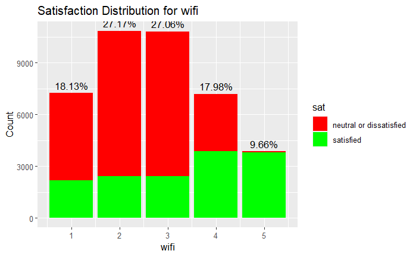

```r
# Inflight Wifi service
plot_bar_chart(df, wifi)
```

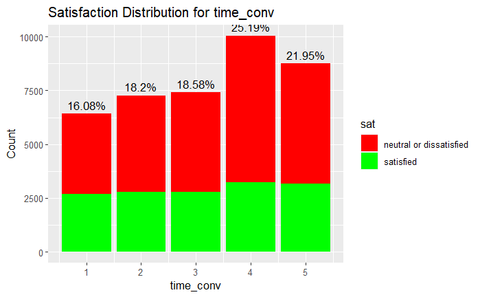

```r
# Departure/arrival time convenient
plot_bar_chart(df, time_conv)
```

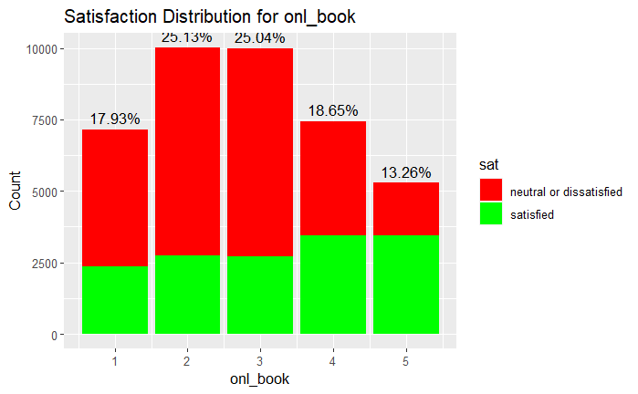

```r
# Ease of online booking
plot_bar_chart(df, onl_book)
```

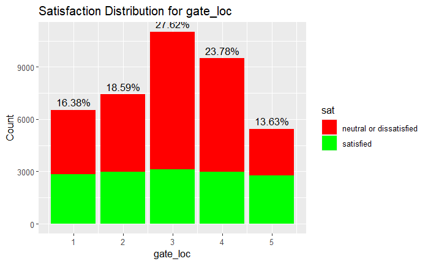

```r
# Gate location
plot_bar_chart(df, gate_loc)
```

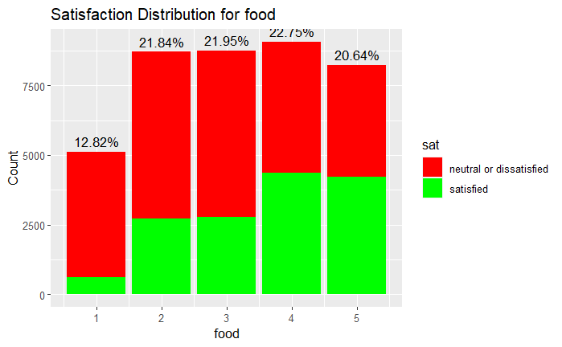

```r
# Food and drink
plot_bar_chart(df, food)
```

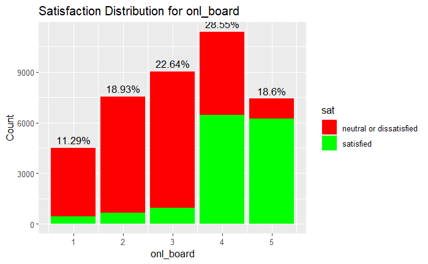

```r
# Online boarding
plot_bar_chart(df, onl_board)
```

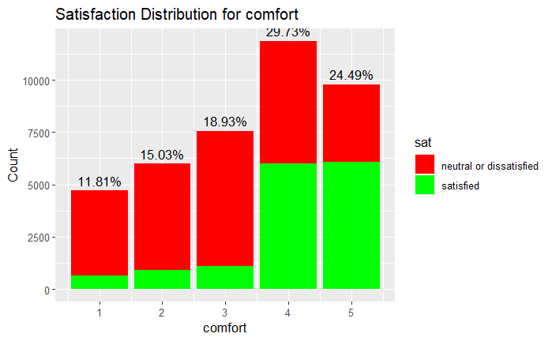

```r
# Seat comfort
plot_bar_chart(df, comfort)
```

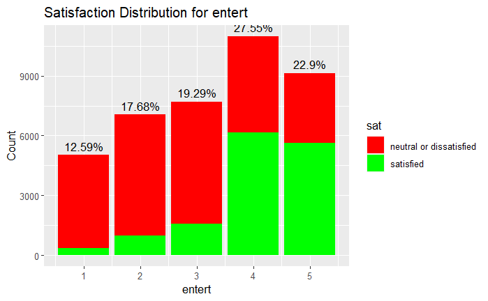

```r
# Inflight entertainment
plot_bar_chart(df, entert)
```

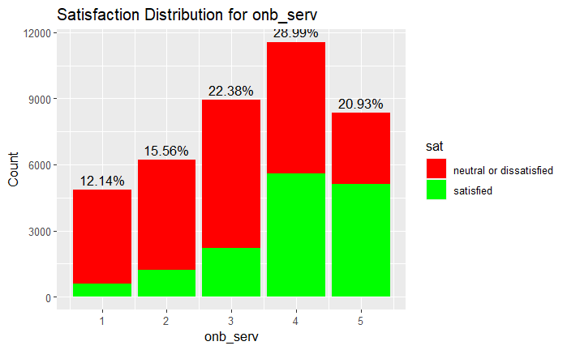

```r
# Onboard service
plot_bar_chart(df, onb_serv)
```

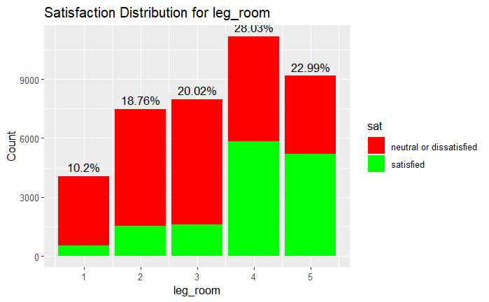

```r
# Leg room service
plot_bar_chart(df, leg_room)
```

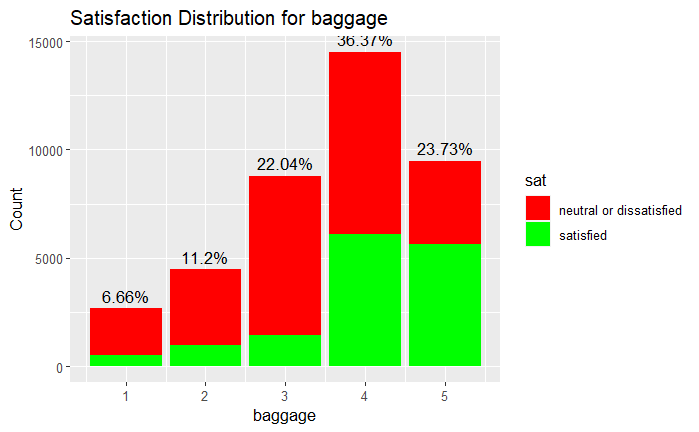

```r
# Baggage handling
plot_bar_chart(df, baggage)
```

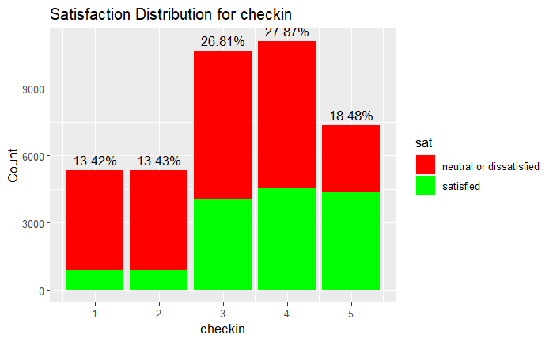

```r
# Check-in service
plot_bar_chart(df, checkin)
```

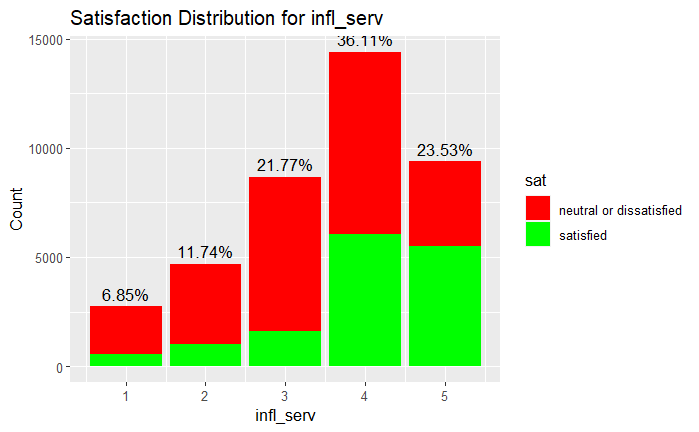

```r
# Inflight service
plot_bar_chart(df, infl_serv)
```

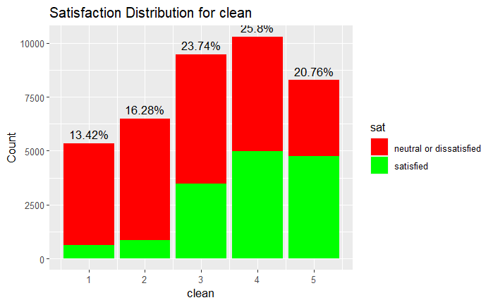

```r
# Cleanliness
plot_bar_chart(df, clean)
```

```r
summary(df)
```

[output not shown]

### Numerical Variables

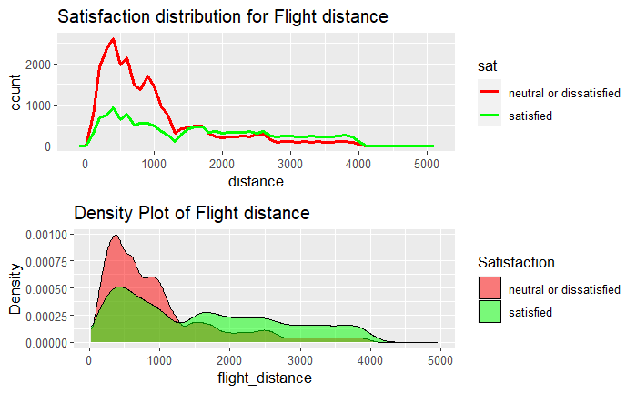

```r
# Flight distance
p_distance <- ggplot(data = df, aes(distance, color = sat)) +
  geom_freqpoly(binwidth = 100, linewidth = 1) +
  scale_color_manual(values = c("red", "green")) +
  labs(title = "Satisfaction distribution for Flight distance")

# Distance density
p_distancr_den <- ggplot(df, aes(x = distance, fill = sat)) +
  geom_density(alpha = 0.5) +
  labs(title = "Density Plot of Flight distance",
       x = "flight_distance", y = "Density") +
  scale_fill_manual(values = c("red", "green"), name = "Satisfaction")

grid.arrange(p_distance, p_distancr_den)
```

[figure not shown]

```r
# Departure delay
# I selected delays under 200 min otherwise the graphs look even worse than these
p_dep_del <- ggplot(data = df[df$dep_delay < 200, ],
                    aes(dep_delay, color = sat)) +
  geom_freqpoly(binwidth = 15, linewidth = 0.7) +
  scale_color_manual(values = c("red", "green")) +
  labs(title = "Satisfaction distribution for Departure delay")
p_dep_del
```

```r
# Arrival delay
p_arr_del <- ggplot(data = df[df$arr_delay < 200, ],
                    aes(arr_delay, color = sat)) +
  geom_freqpoly(binwidth = 15, linewidth = 0.7) +
  scale_color_manual(values = c("red", "green")) +
  labs(title = "Satisfaction distribution for Arrival distance")
```

[output not shown]

[output not shown]

**Before correlation matrix we can encode variables**

```r
df$class_Eco <- ifelse(df$class =="Eco", 1, 0)
df$class_Eco_plus <- ifelse(df$class == "Eco Plus", 1, 0)
df$sat <- ifelse(df$sat == "satisfied", 1, 0)
df$gender <- ifelse(df$gender == "Male", 1, 0)
df$cust_type <- ifelse(df$cust_type == "Loyal Customer", 1, 0)
df$class <- ifelse(df$class == 'Eco', 1, 0)
df$trav_type <- ifelse(df$trav_type == 'Personal Travel', 1, 0)
df <- df %>% select(- class)
df <- df %>% relocate(class_Eco, .after = age)
df <- df %>% relocate(class_Eco_plus, .after = class_Eco)
df
```

| gender | cust_type | age | class_Eco | class_Eco_plus | trav_type | distance | wifi | time_conv | onl_book | gate_loc | food | onl_board | comfort | entert | onb_serv | leg_room | baggage | checkin | infl_serv | clean | arr_delay | sat |
| --- | --- | --- | --- | --- | --- | --- | --- | --- | --- | --- | --- | --- | --- | --- | --- | --- | --- | --- | --- | --- | --- | --- |
| 1 | 0 | 25 | 0 | 0 | 0 | 235 | 3 | 2 | 3 | 3 | 1 | 3 | 1 | 1 | 1 | 5 | 3 | 1 | 4 | 1 | 6 | 0 |
| 0 | 1 | 25 | 0 | 0 | 0 | 562 | 2 | 5 | 5 | 5 | 2 | 2 | 2 | 2 | 2 | 5 | 3 | 1 | 4 | 2 | 9 | 0 |
| 1 | 1 | 47 | 1 | 0 | 1 | 1276 | 2 | 4 | 2 | 3 | 2 | 2 | 2 | 2 | 3 | 3 | 4 | 3 | 5 | 2 | 23 | 0 |
| 1 | 1 | 53 | 1 | 0 | 0 | 834 | 1 | 4 | 4 | 4 | 1 | 1 | 1 | 1 | 1 | 1 | 3 | 4 | 4 | 1 | 8 | 0 |
| 0 | 1 | 26 | 1 | 0 | 1 | 453 | 3 | 2 | 3 | 2 | 2 | 3 | 2 | 2 | 4 | 3 | 2 | 2 | 1 | 2 | 35 | 0 |
| 0 | 1 | 26 | 0 | 0 | 0 | 2123 | 3 | 3 | 3 | 3 | 4 | 4 | 4 | 4 | 5 | 3 | 4 | 5 | 4 | 4 | 51 | 1 |
| 0 | 1 | 45 | 0 | 0 | 0 | 2486 | 4 | 4 | 4 | 4 | 3 | 4 | 5 | 5 | 5 | 5 | 5 | 3 | 5 | 4 | 5 | 1 |
| 1 | 1 | 38 | 1 | 0 | 1 | 460 | 2 | 3 | 3 | 2 | 5 | 3 | 5 | 5 | 1 | 2 | 4 | 3 | 2 | 5 | 18 | 0 |
| 0 | 1 | 43 | 1 | 0 | 1 | 752 | 3 | 5 | 3 | 5 | 5 | 4 | 5 | 3 | 3 | 3 | 5 | 3 | 3 | 4 | 29 | 0 |
| 1 | 1 | 57 | 1 | 0 | 1 | 719 | 4 | 4 | 4 | 1 | 5 | 4 | 5 | 5 | 3 | 2 | 4 | 4 | 5 | 5 | 28 | 0 |

[output cut: 990 more lines]

# Correlation matrix for the customer-generated variables

```r
correlation_matrix <- df %>%
  select(wifi,time_conv,
         onl_book, gate_loc, food, onl_board,
         comfort, entert, onb_serv, leg_room,
         baggage, checkin, infl_serv, clean) %>%
  cor()

round(correlation_matrix, 3)
```

### Heatmap

```r
heatmap(correlation_matrix,
        col = colorRampPalette(c("blue", "white", "red"))(1000),
        main = "Correlation Heatmap", Colv = NA, margins = c(15, 9))
```

[output not shown]

```r
library(PerformanceAnalytics)
chart.Correlation(correlation_matrix)
```

[output not shown]

```r
library(corrplot)
corrplot(cor(correlation_matrix))
```

[output not shown]

## Radar map

```r
exclude_cols <- c("gender", "customer_type", "age", "type_of_travel",
                  "customer_class", "flight_distance",
                  "departure_delay_in_minutes", "arrival_delay_in_minutes")


df_mean <- df %>%
  select(-exclude_cols) %>%
  group_by(satisfaction) %>%
  summarize(across(any_of(names(.)[sapply(., is.numeric) | sapply(., is.logical)]),
                   ~ mean(., na.rm = TRUE)))
df_mean
```

```r
# df_mean[, 2:15]

radarchart(rbind(rep(5, 14), rep(0, 14), df_mean[, 2:15]),
           vlabels = colnames(df_mean[, 2:15]))
```

```r
ggradar(df_mean, grid.min = 0, grid.max = 5,
        axis.label.size = 3,
        group.point.size = 3,
        group.line.width = 1) +
  theme(legend.position = c(1, 0),
        legend.spacing = unit(c(0, 0, 0, 0), "lines"),
        legend.key.size = unit(c(0, 0, 0, 0), "lines"),
        legend.text = element_text(size = 7),
        plot.margin = unit(c(2, 8, 2, 8), "lines")) +
  scale_color_manual(values = c("red", "green"))
```

[output not shown]

# UNSUPERVISED LEARNING

Goal of this part: Use clustering to create group of customer. Problem: if we use the variables as they are it’s complicate to identify groups Solution: PCA to reduce the dimensions

Drop the response variable since we are in unsupervised learning part

```r
df_uns <- df %>% select(- sat)
```

```r
summary(df_uns)
```

```
     gender         cust_type           age         class_Eco      class_Eco_plus     trav_type         distance         wifi
 Min.   :0.0000   Min.   :0.0000   Min.   : 7.0   Min.   :0.0000   Min.   :0.0000   Min.   :0.0000   Min.   :  31   Min.   :1.000
 1st Qu.:0.0000   1st Qu.:1.0000   1st Qu.:27.0   1st Qu.:0.0000   1st Qu.:0.0000   1st Qu.:0.0000   1st Qu.: 442   1st Qu.:2.000
 Median :0.0000   Median :1.0000   Median :40.0   Median :0.0000   Median :0.0000   Median :0.0000   Median : 853   Median :3.000
 Mean   :0.4926   Mean   :0.8328   Mean   :39.6   Mean   :0.4465   Mean   :0.0772   Mean   :0.3044   Mean   :1206   Mean   :2.739
 3rd Qu.:1.0000   3rd Qu.:1.0000   3rd Qu.:51.0   3rd Qu.:1.0000   3rd Qu.:0.0000   3rd Qu.:1.0000   3rd Qu.:1739   3rd Qu.:4.000
 Max.   :1.0000   Max.   :1.0000   Max.   :85.0   Max.   :1.0000   Max.   :1.0000   Max.   :1.0000   Max.   :4963   Max.   :5.000
   time_conv        onl_book        gate_loc          food         onl_board        comfort        entert         onb_serv
 Min.   :1.000   Min.   :1.000   Min.   :1.000   Min.   :1.000   Min.   :1.000   Min.   :1.0   Min.   :1.000   Min.   :1.00
 1st Qu.:2.000   1st Qu.:2.000   1st Qu.:2.000   1st Qu.:2.000   1st Qu.:2.000   1st Qu.:2.0   1st Qu.:2.000   1st Qu.:2.00
 Median :3.000   Median :3.000   Median :3.000   Median :3.000   Median :3.000   Median :4.0   Median :4.000   Median :3.00
 Mean   :3.187   Mean   :2.842   Mean   :2.997   Mean   :3.165   Mean   :3.242   Mean   :3.4   Mean   :3.305   Mean   :3.31
 3rd Qu.:4.000   3rd Qu.:4.000   3rd Qu.:4.000   3rd Qu.:4.000   3rd Qu.:4.000   3rd Qu.:4.0   3rd Qu.:4.000   3rd Qu.:4.00
 Max.   :5.000   Max.   :5.000   Max.   :5.000   Max.   :5.000   Max.   :5.000   Max.   :5.0   Max.   :5.000   Max.   :5.00
    leg_room        baggage         checkin        infl_serv         clean         arr_delay
 Min.   :1.000   Min.   :1.000   Min.   :1.000   Min.   :1.000   Min.   :1.000   Min.   :   1.00
 1st Qu.:2.000   1st Qu.:3.000   1st Qu.:2.000   1st Qu.:3.000   1st Qu.:2.000   1st Qu.:  10.00
 Median :4.000   Median :4.000   Median :3.000   Median :4.000   Median :3.000   Median :  24.00
 Mean   :3.349   Mean   :3.593   Mean   :3.246   Mean   :3.577   Mean   :3.242   Mean   :  42.48
 3rd Qu.:4.000   3rd Qu.:4.000   3rd Qu.:4.000   3rd Qu.:4.000   3rd Qu.:4.000   3rd Qu.:  52.00
 Max.   :5.000   Max.   :5.000   Max.   :5.000   Max.   :5.000   Max.   :5.000   Max.   :1584.00
```

Perform PCA on the data after scaling the variables to have standard deviation one (from the book)

```r
pca <- prcomp(df_uns, scale = TRUE)
```

```r
summary(pca)
```

```
Importance of components:
                          PC1    PC2     PC3     PC4     PC5     PC6     PC7     PC8     PC9    PC10    PC11    PC12    PC13    PC14
Standard deviation     2.0587 1.5530 1.46217 1.34716 1.20507 1.07660 1.00805 1.00448 0.96325 0.95590 0.88615 0.81968 0.69700 0.69125
Proportion of Variance 0.1926 0.1096 0.09718 0.08249 0.06601 0.05268 0.04619 0.04586 0.04217 0.04153 0.03569 0.03054 0.02208 0.02172
Cumulative Proportion  0.1926 0.3023 0.39946 0.48195 0.54796 0.60064 0.64683 0.69270 0.73487 0.77641 0.81210 0.84264 0.86472 0.88644
                          PC15    PC16    PC17    PC18    PC19    PC20    PC21    PC22
Standard deviation     0.66686 0.62837 0.58632 0.56059 0.52402 0.52041 0.50600 0.44640
Proportion of Variance 0.02021 0.01795 0.01563 0.01428 0.01248 0.01231 0.01164 0.00906
Cumulative Proportion  0.90665 0.92460 0.94023 0.95451 0.96699 0.97930 0.99094 1.00000
```

Select the number of components to consider:

[figure not shown]

```r
pve <- 100 * pca$sdev^2 / sum(pca$sdev^2)
par(mfrow = c(1,2))
plot(pve, type = 'o', ylab = 'PVE',
     xlab = "Principal Component", col = "blue")
plot(cumsum(pve), type = "o", ylab = "Cumulative PVE",
     xlab = "Principal Component", col = "brown3")
```

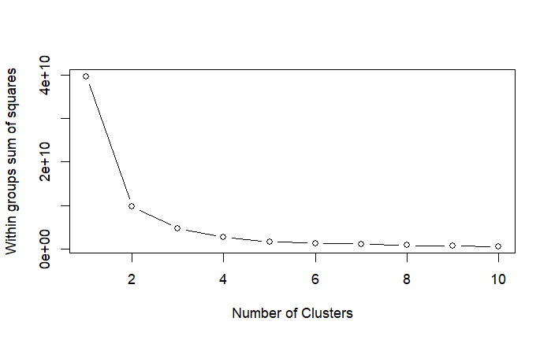

```r
# Determine number of clusters
wss <- (nrow(df_uns)-1)*sum(apply(df_uns,2,var))
for (i in 2:10) wss[i] <- sum(kmeans(df_uns,
                                     centers=i)$withinss)
plot(1:10, wss, type="b", xlab="Number of Clusters",
     ylab="Within groups sum of squares")
```

It looks like we can use 3 cluster

Perform kmeans on the first eleven components: (Plot them against the first two components)

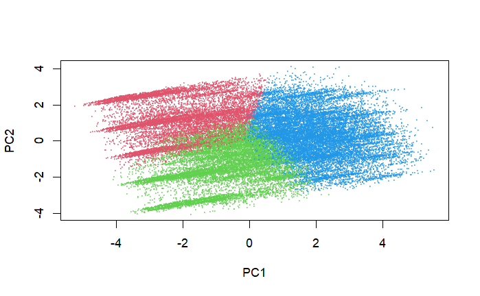

```r
km <- kmeans(pca$x[, 1:11], 3, nstart = 20)
plot(pca$x[,1:2], col = alpha(km$cluster + 1, 0.5), pch = 20, cex = .2)
```

Looks cool, we can add title and stuff.

Add the cluster column to the original df, then plot the satisfaction rate for different clusters:

```r
sort(table(km$clust))
```

```
    1     2     3
10835 12952 16121
```

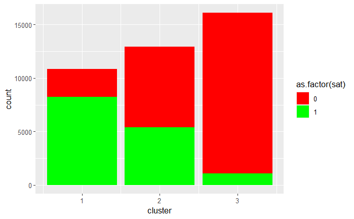

```r
clust <- names(sort(table(km$clust)))
df$cluster = km$clust

ggplot(df, aes(x=cluster)) + geom_bar(aes(fill = as.factor(sat))) + scale_fill_manual(values = c("red", "green"))
```

We can study more this group to reach conclusions.